# SG_01_FUNDRAISER_ADDR_L1

Fundraiser street address line 1 · Text report

## Overview

**Description**

Foreign Address - AddressLine1

**Table**

`SG-P01-T01-FUNDRAISERS-INFO` (many)

**Location code**

`SCHED-G-PART-01-LINE-02B-COL-i`

**Family**

`SCHED-G-PART-01-LINE-02B-COL-i` · siblings: SG_01_FUNDRAISER_ADDR_CITY, SG_01_FUNDRAISER_ADDR_CNTR, SG_01_FUNDRAISER_ADDR_L2, SG_01_FUNDRAISER_ADDR_STATE, SG_01_FUNDRAISER_ADDR_ZIP, SG_01_FUNDRAISER_NAME_INDIV

**Data type**

text (xsd: )

**Scope**

PZ

**Status**

unreviewed

6

xpaths mapped (6 observed)

68,816

filings with a value

2010–2024

tax years observed

4

open flags (1 errors)

## Flags

| Severity | Flag | Xpath | Detail |
| --- | --- | --- | --- |
| ⚠ error | `COLLISION` | IRS990ScheduleG/FundraiserActivityInfoGrp/ForeignAddress/AddressLine1Txt | 577 filings contain 2+ of its xpaths; most common set: /Return/ReturnData/IRS990ScheduleG/FundraiserActivityInfoGrp/ForeignAddress/AddressLine1Txt ; /Return/ReturnData/IRS990ScheduleG/FundraiserActivi… |
| ⓘ info | `MANY_NOT_REPEATING` | IRS990ScheduleG/FundraiserActivityInfoGrp/USAddress/AddressLine1Txt | many-to-one table, but 72% of values sit in no repeating element |
| ⓘ info | `MANY_NOT_REPEATING` | IRS990ScheduleG/FundraiserActivityInformation/AddressUS/AddressLine1 | many-to-one table, but 71% of values sit in no repeating element |
| ⓘ info | `MANY_NOT_REPEATING` | IRS990ScheduleG/FundraiserActivityInfoGrp/USAddress/AddressLine1 | many-to-one table, but 71% of values sit in no repeating element |

## Xpaths

All mapped xpaths (under /Return/ReturnData or /Return/ReturnHeader), oldest first. Charts label each series by its xpath.

| Xpath | Form | Chart label | First year | Last year | Versions | Filings | Repeats in |
| --- | --- | --- | --- | --- | --- | --- | --- |
| IRS990ScheduleG/FundraiserActivityInformation/AddressUS/AddressLine1 | Sched G | …uleG/FundraiserActivityInformation/AddressUS/AddressLine1 | 2010 | 2012 | 12 | 9,547 | 28.5% |
| IRS990ScheduleG/FundraiserActivityInformation/AddressForeign/AddressLine1 | Sched G | …FundraiserActivityInformation/AddressForeign/AddressLine1 | 2010 | 2012 | 9 | 101 | 13.9% |
| IRS990ScheduleG/FundraiserActivityInfoGrp/USAddress/AddressLine1 | Sched G | …cheduleG/FundraiserActivityInfoGrp/USAddress/AddressLine1 | 2013 | 2013 | 3 | 4,040 | 27.6% |
| IRS990ScheduleG/FundraiserActivityInfoGrp/ForeignAddress/AddressLine1 | Sched G | …leG/FundraiserActivityInfoGrp/ForeignAddress/AddressLine1 | 2013 | 2013 | 3 | 41 | 9.8% |
| IRS990ScheduleG/FundraiserActivityInfoGrp/USAddress/AddressLine1Txt | Sched G | …duleG/FundraiserActivityInfoGrp/USAddress/AddressLine1Txt | 2014 | 2024 | 34 | 54,332 | 27.1% |
| IRS990ScheduleG/FundraiserActivityInfoGrp/ForeignAddress/AddressLine1Txt | Sched G | …/FundraiserActivityInfoGrp/ForeignAddress/AddressLine1Txt | 2014 | 2024 | 32 | 755 | 19.1% |

## Coverage

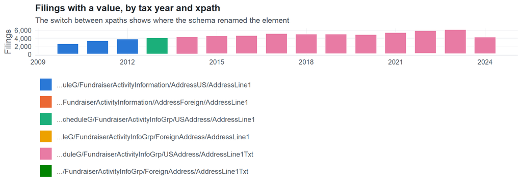

**Table view**

Table view: filings by tax year and series

| Tax year | …uleG/FundraiserActivityInformation/AddressUS/AddressLine1 | …FundraiserActivityInformation/AddressForeign/AddressLine1 | …cheduleG/FundraiserActivityInfoGrp/USAddress/AddressLine1 | …leG/FundraiserActivityInfoGrp/ForeignAddress/AddressLine1 | …duleG/FundraiserActivityInfoGrp/USAddress/AddressLine1Txt | …/FundraiserActivityInfoGrp/ForeignAddress/AddressLine1Txt |
| --- | --- | --- | --- | --- | --- | --- |
| 2010 | 2,546 | 31 | 0 | 0 | 0 | 0 |
| 2011 | 3,261 | 33 | 0 | 0 | 0 | 0 |
| 2012 | 3,740 | 37 | 0 | 0 | 0 | 0 |
| 2013 | 0 | 0 | 4,040 | 41 | 0 | 0 |
| 2014 | 0 | 0 | 0 | 0 | 4,268 | 44 |
| 2015 | 0 | 0 | 0 | 0 | 4,502 | 52 |
| 2016 | 0 | 0 | 0 | 0 | 4,586 | 57 |
| 2017 | 0 | 0 | 0 | 0 | 5,043 | 56 |
| 2018 | 0 | 0 | 0 | 0 | 4,932 | 59 |
| 2019 | 0 | 0 | 0 | 0 | 4,909 | 58 |
| 2020 | 0 | 0 | 0 | 0 | 4,794 | 66 |
| 2021 | 0 | 0 | 0 | 0 | 5,278 | 82 |
| 2022 | 0 | 0 | 0 | 0 | 5,772 | 116 |
| 2023 | 0 | 0 | 0 | 0 | 6,040 | 98 |
| 2024 | 0 | 0 | 0 | 0 | 4,208 | 67 |

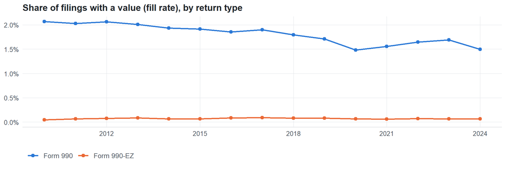

**Table view**

Table view: fill rate

| Tax year | Return type | Filings | All filings | Fill rate |
| --- | --- | --- | --- | --- |
| 2010 | Form 990 | 2,547 | 123,025 | 2.07% |
| 2010 | Form 990-EZ | 30 | 63,326 | 0.05% |
| 2011 | Form 990 | 3,239 | 159,504 | 2.03% |
| 2011 | Form 990-EZ | 55 | 82,048 | 0.07% |
| 2012 | Form 990 | 3,706 | 179,688 | 2.06% |
| 2012 | Form 990-EZ | 71 | 93,750 | 0.08% |
| 2013 | Form 990 | 3,992 | 198,855 | 2.01% |
| 2013 | Form 990-EZ | 89 | 104,375 | 0.09% |
| 2014 | Form 990 | 4,235 | 218,619 | 1.94% |
| 2014 | Form 990-EZ | 77 | 116,417 | 0.07% |
| 2015 | Form 990 | 4,473 | 233,519 | 1.92% |
| 2015 | Form 990-EZ | 81 | 124,894 | 0.06% |
| 2016 | Form 990 | 4,530 | 243,903 | 1.86% |
| 2016 | Form 990-EZ | 113 | 130,484 | 0.09% |
| 2017 | Form 990 | 4,971 | 261,612 | 1.90% |
| 2017 | Form 990-EZ | 128 | 139,144 | 0.09% |
| 2018 | Form 990 | 4,869 | 271,442 | 1.79% |
| 2018 | Form 990-EZ | 122 | 149,384 | 0.08% |
| 2019 | Form 990 | 4,848 | 283,694 | 1.71% |
| 2019 | Form 990-EZ | 119 | 152,622 | 0.08% |
| 2020 | Form 990 | 4,749 | 320,342 | 1.48% |
| 2020 | Form 990-EZ | 111 | 169,864 | 0.07% |
| 2021 | Form 990 | 5,235 | 336,480 | 1.56% |
| 2021 | Form 990-EZ | 125 | 202,724 | 0.06% |
| 2022 | Form 990 | 5,739 | 349,055 | 1.64% |
| 2022 | Form 990-EZ | 149 | 206,130 | 0.07% |
| 2023 | Form 990 | 6,008 | 354,768 | 1.69% |
| 2023 | Form 990-EZ | 130 | 206,379 | 0.06% |
| 2024 | Form 990 | 4,159 | 277,298 | 1.50% |
| 2024 | Form 990-EZ | 116 | 178,867 | 0.06% |

## Repeating groups

Table cardinality in the concordance: **many**. 6 of 6 observed xpaths repeat within a filing.

Repeating element each xpath was observed in (from the raw indexed xpath)

| Xpath | Repeating element | Filings (summed over years) |
| --- | --- | --- |
| IRS990ScheduleG/FundraiserActivityInformation/AddressForeign/AddressLine1 | (none) | 34 |
| IRS990ScheduleG/FundraiserActivityInformation/AddressForeign/AddressLine1 | IRS990ScheduleG/FundraiserActivityInformation | 67 |
| IRS990ScheduleG/FundraiserActivityInformation/AddressUS/AddressLine1 | (none) | 6758 |
| IRS990ScheduleG/FundraiserActivityInformation/AddressUS/AddressLine1 | IRS990ScheduleG/FundraiserActivityInformation | 2789 |
| IRS990ScheduleG/FundraiserActivityInfoGrp/ForeignAddress/AddressLine1 | (none) | 18 |
| IRS990ScheduleG/FundraiserActivityInfoGrp/ForeignAddress/AddressLine1 | IRS990ScheduleG/FundraiserActivityInfoGrp | 23 |
| IRS990ScheduleG/FundraiserActivityInfoGrp/USAddress/AddressLine1 | (none) | 2886 |
| IRS990ScheduleG/FundraiserActivityInfoGrp/USAddress/AddressLine1 | IRS990ScheduleG/FundraiserActivityInfoGrp | 1154 |
| IRS990ScheduleG/FundraiserActivityInfoGrp/ForeignAddress/AddressLine1Txt | (none) | 220 |
| IRS990ScheduleG/FundraiserActivityInfoGrp/ForeignAddress/AddressLine1Txt | IRS990ScheduleG/FundraiserActivityInfoGrp | 535 |
| IRS990ScheduleG/FundraiserActivityInfoGrp/USAddress/AddressLine1Txt | (none) | 39016 |
| IRS990ScheduleG/FundraiserActivityInfoGrp/USAddress/AddressLine1Txt | IRS990ScheduleG/FundraiserActivityInfoGrp | 15316 |

## Values

| Result | Check | Detail |
| --- | --- | --- |
| ✓ pass | Values are text, not numbers | 0% of values are numeric |
| ⓘ info | No sign of truncation | …/FundraiserActivityInfoGrp/ForeignAddress/AddressLine1Txt: longest value is exactly 35 characters; …cheduleG/FundraiserActivityInfoGrp/USAddress/AddressLine1: longest value is exactly 35 characters; … |
| ✓ pass | No dominant boilerplate value | most common value covers 7% of filings: “123 Woolwich St” |

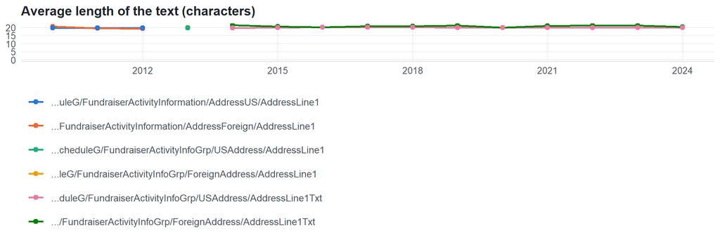

**Table view**

Table view: length and variety by tax year

| Series | Tax year | Filings | Avg length | Max length | Distinct values (approx.) |
| --- | --- | --- | --- | --- | --- |
| …uleG/FundraiserActivityInformation/AddressUS/AddressLine1 | 2010 | 2,546 | 20 | 35 | 2,016 |
| …uleG/FundraiserActivityInformation/AddressUS/AddressLine1 | 2011 | 3,261 | 20 | 35 | 2,332 |
| …uleG/FundraiserActivityInformation/AddressUS/AddressLine1 | 2012 | 3,740 | 20 | 35 | 3,386 |
| …FundraiserActivityInformation/AddressForeign/AddressLine1 | 2010 | 31 | 21 | 34 | 24 |
| …FundraiserActivityInformation/AddressForeign/AddressLine1 | 2011 | 33 | 20 | 32 | 22 |
| …FundraiserActivityInformation/AddressForeign/AddressLine1 | 2012 | 37 | 19 | 33 | 22 |
| …cheduleG/FundraiserActivityInfoGrp/USAddress/AddressLine1 | 2013 | 4,040 | 20 | 35 | 2,299 |
| …leG/FundraiserActivityInfoGrp/ForeignAddress/AddressLine1 | 2013 | 41 | 20 | 34 | 25 |
| …duleG/FundraiserActivityInfoGrp/USAddress/AddressLine1Txt | 2014 | 4,268 | 20 | 35 | 3,004 |
| …duleG/FundraiserActivityInfoGrp/USAddress/AddressLine1Txt | 2015 | 4,502 | 20 | 35 | 2,869 |
| …duleG/FundraiserActivityInfoGrp/USAddress/AddressLine1Txt | 2016 | 4,586 | 20 | 35 | 4,994 |
| …duleG/FundraiserActivityInfoGrp/USAddress/AddressLine1Txt | 2017 | 5,043 | 20 | 35 | 3,847 |
| …duleG/FundraiserActivityInfoGrp/USAddress/AddressLine1Txt | 2018 | 4,932 | 20 | 35 | 5,564 |
| …duleG/FundraiserActivityInfoGrp/USAddress/AddressLine1Txt | 2019 | 4,909 | 20 | 35 | 3,090 |
| …duleG/FundraiserActivityInfoGrp/USAddress/AddressLine1Txt | 2020 | 4,794 | 20 | 35 | 3,010 |
| …duleG/FundraiserActivityInfoGrp/USAddress/AddressLine1Txt | 2021 | 5,278 | 20 | 35 | 4,209 |
| …duleG/FundraiserActivityInfoGrp/USAddress/AddressLine1Txt | 2022 | 5,772 | 20 | 35 | 5,993 |
| …duleG/FundraiserActivityInfoGrp/USAddress/AddressLine1Txt | 2023 | 6,040 | 20 | 35 | 3,230 |
| …duleG/FundraiserActivityInfoGrp/USAddress/AddressLine1Txt | 2024 | 4,208 | 20 | 35 | 2,664 |
| …/FundraiserActivityInfoGrp/ForeignAddress/AddressLine1Txt | 2014 | 44 | 21 | 34 | 36 |
| …/FundraiserActivityInfoGrp/ForeignAddress/AddressLine1Txt | 2015 | 52 | 21 | 35 | 31 |
| …/FundraiserActivityInfoGrp/ForeignAddress/AddressLine1Txt | 2016 | 57 | 20 | 34 | 55 |
| …/FundraiserActivityInfoGrp/ForeignAddress/AddressLine1Txt | 2017 | 56 | 21 | 35 | 83 |
| …/FundraiserActivityInfoGrp/ForeignAddress/AddressLine1Txt | 2018 | 59 | 21 | 34 | 47 |
| …/FundraiserActivityInfoGrp/ForeignAddress/AddressLine1Txt | 2019 | 58 | 21 | 34 | 35 |
| …/FundraiserActivityInfoGrp/ForeignAddress/AddressLine1Txt | 2020 | 66 | 20 | 34 | 37 |
| …/FundraiserActivityInfoGrp/ForeignAddress/AddressLine1Txt | 2021 | 82 | 21 | 34 | 65 |
| …/FundraiserActivityInfoGrp/ForeignAddress/AddressLine1Txt | 2022 | 116 | 21 | 35 | 123 |
| …/FundraiserActivityInfoGrp/ForeignAddress/AddressLine1Txt | 2023 | 98 | 21 | 35 | 61 |
| …/FundraiserActivityInfoGrp/ForeignAddress/AddressLine1Txt | 2024 | 67 | 20 | 35 | 51 |

Most common values by xpath (all years; long values truncated)

| Series | Value | Filings | Share |
| --- | --- | --- | --- |
| …uleG/FundraiserActivityInformation/AddressUS/AddressLine1 | 65 KIRKWOOD NORTH ROAD SW | 104 | 1.1% |
| …uleG/FundraiserActivityInformation/AddressUS/AddressLine1 | 1200 WALL STREET WEST | 65 | 0.7% |
| …uleG/FundraiserActivityInformation/AddressUS/AddressLine1 | PO BOX 3018 | 62 | 0.6% |
| …uleG/FundraiserActivityInformation/AddressUS/AddressLine1 | PO Box 3018 | 43 | 0.5% |
| …uleG/FundraiserActivityInformation/AddressUS/AddressLine1 | 7251 OHMS LANE | 39 | 0.4% |
| …uleG/FundraiserActivityInformation/AddressUS/AddressLine1 | 6715 SUNSET BLVD | 36 | 0.4% |
| …uleG/FundraiserActivityInformation/AddressUS/AddressLine1 | PO BOX 27462 | 29 | 0.3% |
| …uleG/FundraiserActivityInformation/AddressUS/AddressLine1 | 65 KIRKWOOD NORTH RD SW | 25 | 0.3% |
| …uleG/FundraiserActivityInformation/AddressUS/AddressLine1 | 325 SPRINGSIDE DRIVE | 21 | 0.2% |
| …uleG/FundraiserActivityInformation/AddressUS/AddressLine1 | 3190 RIDER TRAIL SOUTH | 13 | 0.1% |
| …uleG/FundraiserActivityInformation/AddressUS/AddressLine1 | 501 GATEWAY DRIVE SUITE A | 13 | 0.1% |
| …uleG/FundraiserActivityInformation/AddressUS/AddressLine1 | 717 WEST ST GERMAIN STREET | 11 | 0.1% |
| …uleG/FundraiserActivityInformation/AddressUS/AddressLine1 | 1511 ROUTE 22 SUITE C-25 | 9 | 0.1% |
| …uleG/FundraiserActivityInformation/AddressUS/AddressLine1 | 5757 W CENTURY BLVD SUITE 300 | 9 | 0.1% |
| …uleG/FundraiserActivityInformation/AddressUS/AddressLine1 | 1200 Wall Street West | 9 | 0.1% |
| …uleG/FundraiserActivityInformation/AddressUS/AddressLine1 | 5757 WEST CENTURY BLVD SUITE 300 | 8 | 0.1% |
| …FundraiserActivityInformation/AddressForeign/AddressLine1 | 123 Woolwich St | 7 | 6.9% |
| …FundraiserActivityInformation/AddressForeign/AddressLine1 | 260 KING ST EAST STE 500 | 6 | 5.9% |
| …FundraiserActivityInformation/AddressForeign/AddressLine1 | 184 Front Street East | 3 | 3.0% |
| …FundraiserActivityInformation/AddressForeign/AddressLine1 | 123 WOOLRICH STREET | 2 | 2.0% |
| …FundraiserActivityInformation/AddressForeign/AddressLine1 | 1595 ROUTE 85 | 2 | 2.0% |
| …FundraiserActivityInformation/AddressForeign/AddressLine1 | 211 OLD STREET | 2 | 2.0% |
| …FundraiserActivityInformation/AddressForeign/AddressLine1 | 121 HUBLEY MILL LAKE ROAD | 2 | 2.0% |
| …FundraiserActivityInformation/AddressForeign/AddressLine1 | 105-15 INNOVATION BOULEVARD | 1 | 1.0% |
| …FundraiserActivityInformation/AddressForeign/AddressLine1 | 10A Hardy Road | 1 | 1.0% |
| …FundraiserActivityInformation/AddressForeign/AddressLine1 | 1600 BEACH DOUGLAS HOUSE SUITE 220 | 1 | 1.0% |
| …FundraiserActivityInformation/AddressForeign/AddressLine1 | 16175 LOYALIST PARKWAY-RR2 | 1 | 1.0% |
| …FundraiserActivityInformation/AddressForeign/AddressLine1 | 101 Old Colony Road | 1 | 1.0% |
| …FundraiserActivityInformation/AddressForeign/AddressLine1 | 16-12 GINZA 7-CHOME | 1 | 1.0% |
| …FundraiserActivityInformation/AddressForeign/AddressLine1 | 179 JOHN STREET STE 301A | 1 | 1.0% |

First rows shown.

## Examples

| Tax year | Return | Xpath | Organization | Value | Source |
| --- | --- | --- | --- | --- | --- |
| 2024 | 990 | IRS990ScheduleG/FundraiserActivityInfoGrp/ForeignAddress/AddressLine1Txt | PROVEG INTERNATIONAL INC | JOAO LUIS DE MOURA 22 | [XML](https://gt990datalake-rawdata.s3.amazonaws.com/EfileData/XmlFiles/202512889349300611_public.xml) |
| 2024 | 990 | IRS990ScheduleG/FundraiserActivityInfoGrp/USAddress/AddressLine1Txt | THE CLEVELAND CLINIC FOUNDATION | 350 TENTH AVE STE 1300 | [XML](https://gt990datalake-rawdata.s3.amazonaws.com/EfileData/XmlFiles/202513189349302136_public.xml) |
| 2023 | 990 | IRS990ScheduleG/FundraiserActivityInfoGrp/ForeignAddress/AddressLine1Txt | ALIMENTA LA SOLIDARIDAD INC | Federal Mexico Toluca 5238 | [XML](https://gt990datalake-rawdata.s3.amazonaws.com/EfileData/XmlFiles/202401289349302345_public.xml) |
| 2023 | 990 | IRS990ScheduleG/FundraiserActivityInfoGrp/USAddress/AddressLine1Txt | FITMONEY INC | 20 BOW ST APT 3 | [XML](https://gt990datalake-rawdata.s3.amazonaws.com/EfileData/XmlFiles/202540279349300419_public.xml) |
| 2022 | 990 | IRS990ScheduleG/FundraiserActivityInfoGrp/ForeignAddress/AddressLine1Txt | MUSEUM OF THE BIBLE | SHDEROT CHEN 42 APT 5 | [XML](https://gt990datalake-rawdata.s3.amazonaws.com/EfileData/XmlFiles/202321789349300837_public.xml) |
| 2022 | 990 | IRS990ScheduleG/FundraiserActivityInfoGrp/USAddress/AddressLine1Txt | STATE POLICY NETWORK | 2127 CALIFORNIA STREET NW SUITE 1 | [XML](https://gt990datalake-rawdata.s3.amazonaws.com/EfileData/XmlFiles/202321929349300837_public.xml) |
| 2021 | 990 | IRS990ScheduleG/FundraiserActivityInfoGrp/ForeignAddress/AddressLine1Txt | TIDES CENTER | 7128 PLANK AVE | [XML](https://gt990datalake-rawdata.s3.amazonaws.com/EfileData/XmlFiles/202203189349311670_public.xml) |
| 2021 | 990 | IRS990ScheduleG/FundraiserActivityInfoGrp/USAddress/AddressLine1Txt | NATIONAL ABORTION FEDERATION | ONE THOMAS CIRCLE SUITE 700 | [XML](https://gt990datalake-rawdata.s3.amazonaws.com/EfileData/XmlFiles/202222909349301502_public.xml) |
| 2020 | 990 | IRS990ScheduleG/FundraiserActivityInfoGrp/ForeignAddress/AddressLine1Txt | Mercy Ships | Planetenweg 99 | [XML](https://gt990datalake-rawdata.s3.amazonaws.com/EfileData/XmlFiles/202132099349300133_public.xml) |
| 2020 | 990 | IRS990ScheduleG/FundraiserActivityInfoGrp/USAddress/AddressLine1Txt | National Redistricting Action Fund | 1809 Bay Street SE | [XML](https://gt990datalake-rawdata.s3.amazonaws.com/EfileData/XmlFiles/202221369349307752_public.xml) |
| 2019 | 990 | IRS990ScheduleG/FundraiserActivityInfoGrp/ForeignAddress/AddressLine1Txt | KNOX AREA RESCUE MINISTRIES INC | 5524 ST PATRICK ST SUITE 150 | [XML](https://gt990datalake-rawdata.s3.amazonaws.com/EfileData/XmlFiles/202120579349300537_public.xml) |
| 2019 | 990 | IRS990ScheduleG/FundraiserActivityInfoGrp/USAddress/AddressLine1Txt | CEDARS-SINAI MEDICAL CENTER | 5670 WILSHIRE 1590 | [XML](https://gt990datalake-rawdata.s3.amazonaws.com/EfileData/XmlFiles/202131349349305998_public.xml) |

## Reviewer checklist

- The definition matches the form line and instructions for every xpath’s schema years.
- Every xpath pooled here measures the same thing on the 990 and 990-EZ (close enough for analysis).
- The coverage chart has no unexplained gaps or jumps between tax years.
- Each open flag is fixed, or accepted with a note in validation_log.csv.
- Values answer the question on the form line (not another line’s explanation).
- Boilerplate such as ‘See Schedule O’ or ‘N/A’ is expected here, or should be treated as missing.
- Text that is really a number or a code is flagged for a different data type.

Record the review as a row in `inst/extdata/src/validation_log.csv` (variable_name, reviewer, date, status, note). Evidence built 2026-09-23 17:09:04 MST from the ef2 DuckDB builds (tax years 2009–2024).